# HW13

許循閒

2019年5月27日

## checkpoint_3_forcats

```r
library(tidyverse)
library(tidyquant)
bike_orderlines_tbl <- read_rds("data_wrangled_student/bike_orderlines.rds")
bike_orderlines_tbl
```

```
## # A tibble: 15,644 x 13
##    order_date          order_id order_line quantity price total_price model
##    <dttm>                 <dbl>      <dbl>    <dbl> <dbl>       <dbl> <chr>
##  1 2011-01-07 00:00:00        1          1        1  6070        6070 Jeky~
##  2 2011-01-07 00:00:00        1          2        1  5970        5970 Trig~
##  3 2011-01-10 00:00:00        2          1        1  2770        2770 Beas~
##  4 2011-01-10 00:00:00        2          2        1  5970        5970 Trig~
##  5 2011-01-10 00:00:00        3          1        1 10660       10660 Supe~
##  6 2011-01-10 00:00:00        3          2        1  3200        3200 Jeky~
##  7 2011-01-10 00:00:00        3          3        1 12790       12790 Supe~
##  8 2011-01-10 00:00:00        3          4        1  5330        5330 Supe~
##  9 2011-01-10 00:00:00        3          5        1  1570        1570 Syna~
## 10 2011-01-11 00:00:00        4          1        1  4800        4800 Syna~
## # ... with 15,634 more rows, and 6 more variables: category_1 <chr>,
## #   category_2 <chr>, frame_material <chr>, bikeshop_name <chr>,
## #   city <chr>, state <chr>
```

# 讀取資料

執行tidyverse、tidyquant

用read_rds 讀取bike_orderlines.rds 資料

```r
sales_by_cat_2_tbl <- bike_orderlines_tbl %>%
    select(category_2, total_price) %>%
    group_by(category_2) %>%
    summarize(sales = sum(total_price)) %>%
    ungroup() %>%
    arrange(desc(sales)) %>%
    mutate(category_2 = category_2 %>% as_factor() %>% fct_rev())
```

# Manipulation

用select函數選擇需要的欄位

用mutate函數新增新的欄位資料

用summarize函數總整所有資料

用group_by函數 - 群組起來

用arrange函數將資料排列整理

desc函數 - 由大到小排列

fct_rev() - 反轉資料

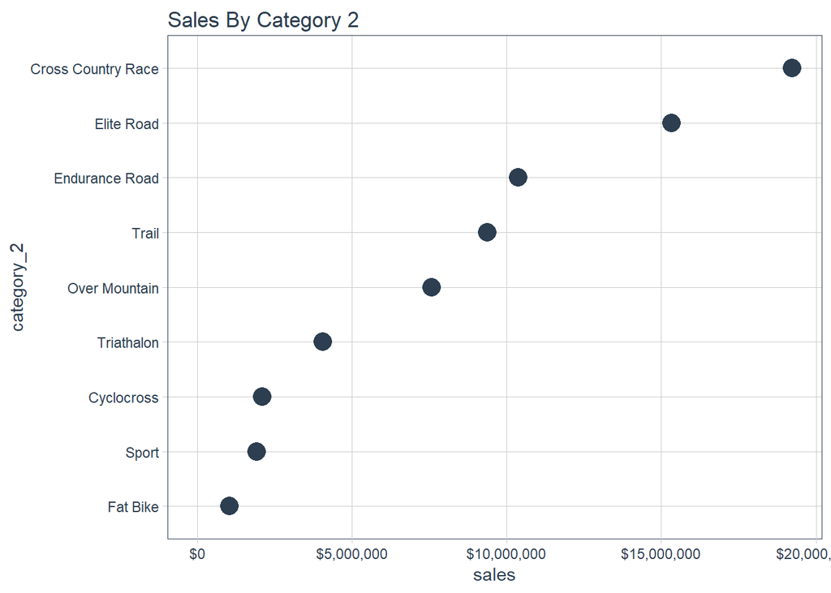

```r
sales_by_cat_2_tbl %>%
    ggplot(aes(x = sales, y = category_2)) +
    geom_point(size = 5, color = "#2c3e50") +
    labs(title = "Sales By Category 2") +
    scale_x_continuous(labels = scales::dollar_format()) +
    theme_tq() +
    expand_limits(x = 0)
```

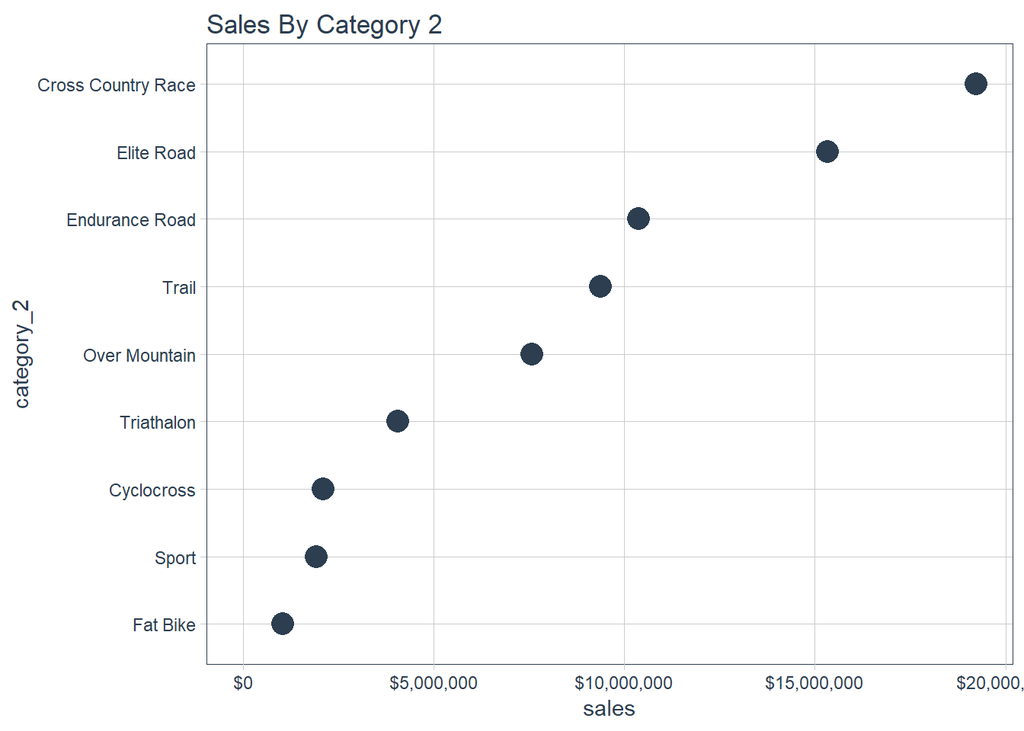

```r
plot_sales <- function(data) {
    data %>%
        ggplot(aes(x = sales, y = category_2)) +
        geom_point(size = 5, color = "#2c3e50") +
        labs(title = "Sales By Category 2") +
        scale_x_continuous(labels = scales::dollar_format()) +
        theme_tq() +
        expand_limits(x = 0)
}

sales_by_cat_2_tbl %>%
    plot_sales()
```

# Plotting

用geom_point函數畫點

theme_tq() - 美化圖表

plot_sales <- function(data) - 設定函數方便使用

```r
sales_by_cat_2_tbl %>% pull(category_2) %>% levels()
```

```
## [1] "Fat Bike"           "Sport"              "Cyclocross"
## [4] "Triathalon"         "Over Mountain"      "Trail"
## [7] "Endurance Road"     "Elite Road"         "Cross Country Race"
```

```r
sales_by_cat_2_tbl %>% pull(category_2) %>% as.numeric()
```

```
## [1] 9 8 7 6 5 4 3 2 1
```

# Vector

pull函數 - 將資料拉出

as.numeric() - 數字形式

```r
sales_by_cat_2_tbl %>%
    mutate(category_2 = category_2 %>% fct_rev() %>% fct_rev()) %>%
    mutate(
        label = category_2 %>% as.character(),
        value = category_2 %>% as.numeric()
    )
```

```
## # A tibble: 9 x 4
##   category_2            sales label              value
##   <fct>                 <dbl> <chr>              <dbl>
## 1 Cross Country Race 19224630 Cross Country Race     9
## 2 Elite Road         15334665 Elite Road             8
## 3 Endurance Road     10381060 Endurance Road         7
## 4 Trail               9373460 Trail                  6
## 5 Over Mountain       7571270 Over Mountain          5
## 6 Triathalon          4053750 Triathalon             4
## 7 Cyclocross          2108120 Cyclocross             3
## 8 Sport               1932755 Sport                  2
## 9 Fat Bike            1052620 Fat Bike               1
```

# Tibble

用mutate函數新增新的欄位資料

label為文字形式

value為數字形式

```r
sales_by_cat_2_tbl %>%
    mutate(
        category_2           = as.character(category_2),
        category_2_as_factor = as_factor(category_2) %>% as.numeric(),
        category_2_as.factor = as.factor(category_2) %>% as.numeric()
    )
```

```
## # A tibble: 9 x 4
##   category_2            sales category_2_as_factor category_2_as.factor
##   <chr>                 <dbl>                <dbl>                <dbl>
## 1 Cross Country Race 19224630                    1                    1
## 2 Elite Road         15334665                    2                    3
## 3 Endurance Road     10381060                    3                    4
## 4 Trail               9373460                    4                    8
## 5 Over Mountain       7571270                    5                    6
## 6 Triathalon          4053750                    6                    9
## 7 Cyclocross          2108120                    7                    2
## 8 Sport               1932755                    8                    7
## 9 Fat Bike            1052620                    9                    5
```

# Creating Factors: as_factor() vs as.factor()

用mutate函數新增新的欄位資料

category_2為文字形式

category_2_as_factor、category_2_as.factor為數字形式

as_factor - 以原本的排列作排列

as.factor - 以英文字母排列

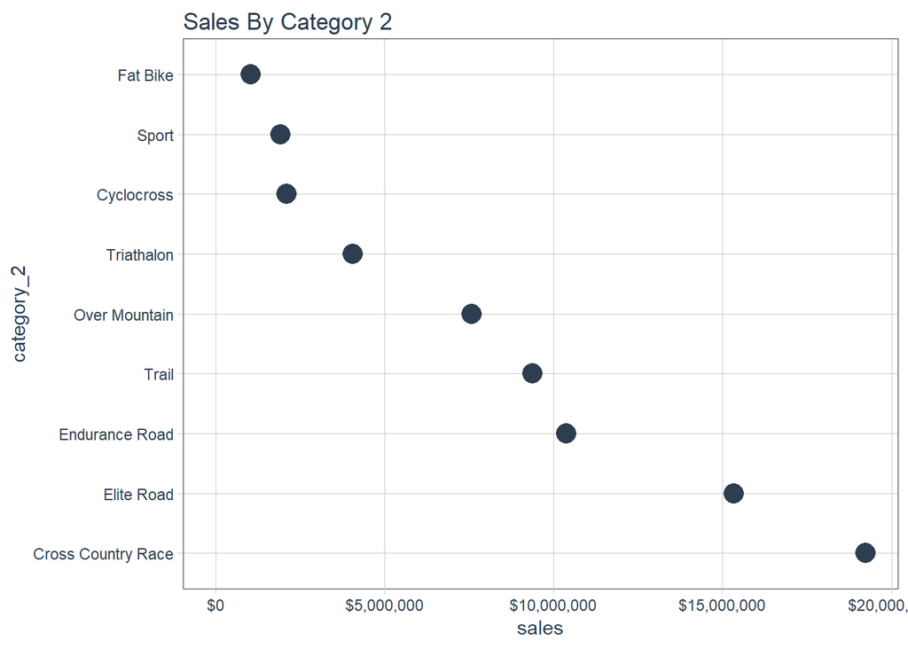

```r
sales_by_cat_2_tbl %>%
    arrange(desc(sales)) %>%
    mutate(sales_negative = -sales) %>%
    mutate(
        category_2 = category_2 %>% fct_reorder(sales_negative),
        values     = category_2 %>% as.numeric()) %>%
    plot_sales()
```

# Reordering Factors: fct_reorder() and fct_rev()

用arrange函數將資料排列整理

desc函數 - 由大到小排列

用mutate函數新增新的欄位資料

fct_reorder函數 - 針對因子排序

```r
sales_by_cat_2_q_tbl <- bike_orderlines_tbl %>%
    mutate(order_date = order_date %>% floor_date("quarter") %>% ymd()) %>%
    group_by(category_2, order_date) %>%
    summarise(sales = sum(total_price)) %>%
    ungroup()

sales_by_cat_2_q_tbl
```

```
## # A tibble: 180 x 3
##    category_2         order_date   sales
##    <chr>              <date>       <dbl>
##  1 Cross Country Race 2011-01-01  610060
##  2 Cross Country Race 2011-04-01 1083310
##  3 Cross Country Race 2011-07-01  609770
##  4 Cross Country Race 2011-10-01  614110
##  5 Cross Country Race 2012-01-01  731330
##  6 Cross Country Race 2012-04-01 1097010
##  7 Cross Country Race 2012-07-01 1000220
##  8 Cross Country Race 2012-10-01  532240
##  9 Cross Country Race 2013-01-01 1017470
## 10 Cross Country Race 2013-04-01 1503950
## # ... with 170 more rows
```

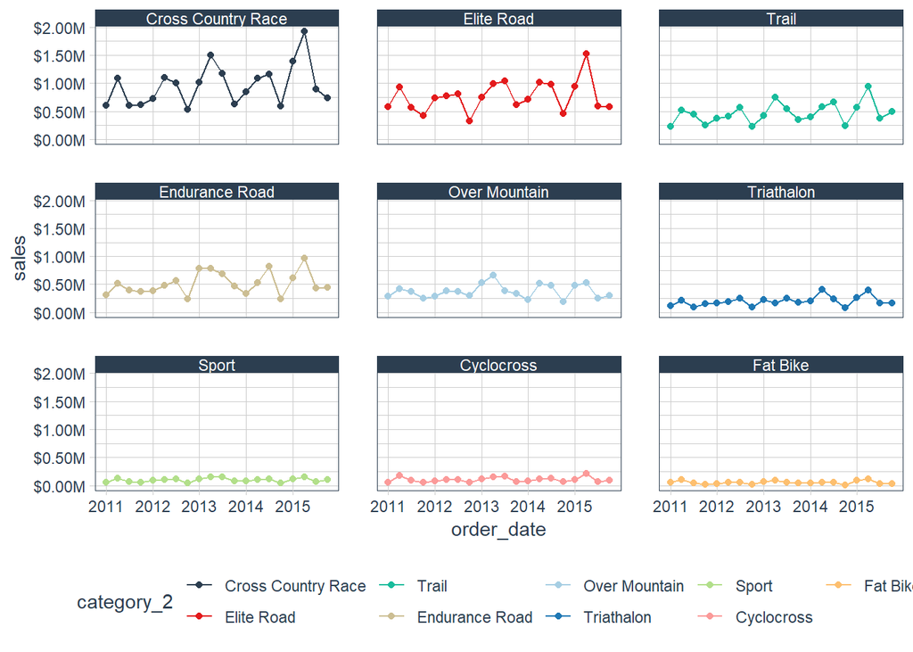

```r
sales_by_cat_2_q_tbl %>%
    mutate(category_2 = category_2 %>% fct_reorder2(order_date, sales)) %>%
    ggplot(aes(x = order_date, y = sales, color = category_2)) +
    geom_point() +
    geom_line() +
    facet_wrap(~ category_2) +
    theme_tq() +
    scale_color_tq() +
    scale_y_continuous(labels = scales::dollar_format(scale = 1e-6, suffix = "M"))
```

# Time-Based Reordering: fct_reorder2()

用mutate函數新增新的欄位資料

用summarize函數總整所有資料

用group_by函數 - 群組起來

用geom_point函數畫點

用geom_line函數畫線

facet_wrap函數 - 打資料分成很多小圖

theme_tq() 、scale_color_tq()美化圖表

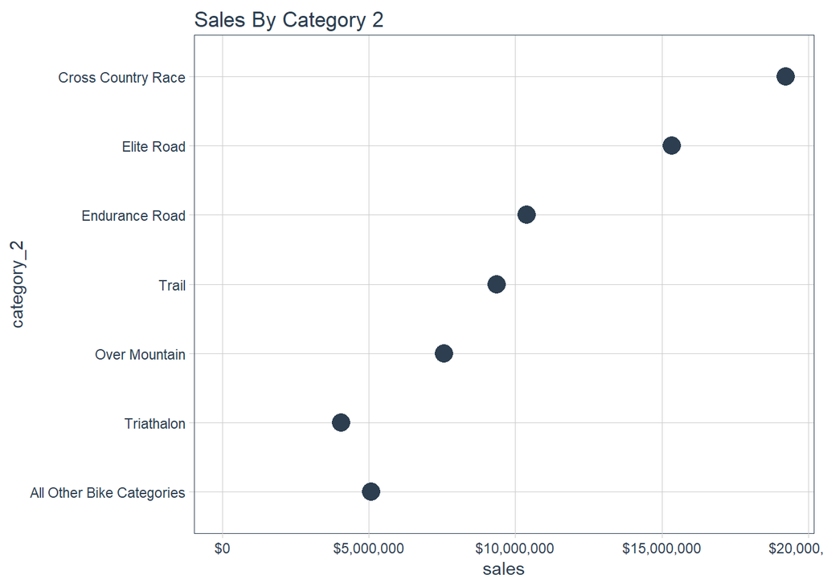

```r
sales_by_cat_2_tbl %>%
    mutate(category_2 = category_2 %>% fct_lump(n = 6,
                                                w = sales,
                                                other_level = "All Other Bike Categories")) %>%
    group_by(category_2) %>%
    summarize(sales = sum(sales)) %>%
    mutate(category_2 = category_2 %>% fct_relevel("All Other Bike Categories", after = 0)) %>%
    plot_sales()
```

# Creating “Other” Category - fct_lump() & fct_relevel()

用mutate函數新增新的欄位資料

用summarize函數總整所有資料

用group_by函數 - 群組起來

fct_lump函數 - 把資料堆疊

fct_relevel函數 - 把資料重新排序

## 02_ggplot_geometries_1

```r
library(tidyverse)
library(lubridate)
library(tidyquant)

bike_orderlines_tbl <- read_rds("data_wrangled_student/bike_orderlines.rds")
glimpse(bike_orderlines_tbl)
```

```
## Observations: 15,644
## Variables: 13
## $ order_date     <dttm> 2011-01-07, 2011-01-07, 2011-01-10, 2011-01-10...
## $ order_id       <dbl> 1, 1, 2, 2, 3, 3, 3, 3, 3, 4, 5, 5, 5, 5, 6, 6,...
## $ order_line     <dbl> 1, 2, 1, 2, 1, 2, 3, 4, 5, 1, 1, 2, 3, 4, 1, 2,...
## $ quantity       <dbl> 1, 1, 1, 1, 1, 1, 1, 1, 1, 1, 1, 2, 1, 1, 1, 1,...
## $ price          <dbl> 6070, 5970, 2770, 5970, 10660, 3200, 12790, 533...
## $ total_price    <dbl> 6070, 5970, 2770, 5970, 10660, 3200, 12790, 533...
## $ model          <chr> "Jekyll Carbon 2", "Trigger Carbon 2", "Beast o...
## $ category_1     <chr> "Mountain", "Mountain", "Mountain", "Mountain",...
## $ category_2     <chr> "Over Mountain", "Over Mountain", "Trail", "Ove...
## $ frame_material <chr> "Carbon", "Carbon", "Aluminum", "Carbon", "Carb...
## $ bikeshop_name  <chr> "Ithaca Mountain Climbers", "Ithaca Mountain Cl...
## $ city           <chr> "Ithaca", "Ithaca", "Kansas City", "Kansas City...
## $ state          <chr> "NY", "NY", "KS", "KS", "KY", "KY", "KY", "KY",...
```

# 讀取資料

執行tidyverse、tidyquant、lubridate

用read_rds 讀取bike_orderlines.rds 資料

```r
order_value_tbl <- bike_orderlines_tbl %>%
    select(order_id, order_line, total_price, quantity) %>%
    group_by(order_id) %>%
    summarize(
        total_quantity = sum(quantity),
        total_price    = sum(total_price)
    ) %>%
    ungroup()
```

# Data Manipulation(Explain relationship between order value and quantity of bikes sold)

用select函數選擇需要的欄位

用summarize函數總整所有資料

用group_by函數 - 群組起來

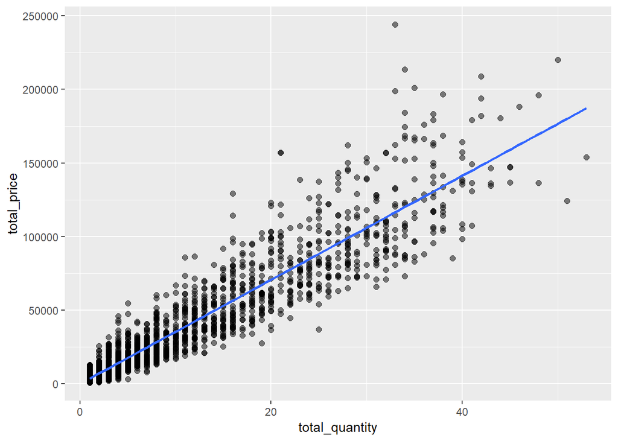

```r
order_value_tbl %>%
    ggplot(aes(x = total_quantity, y = total_price)) +
    geom_point(alpha = 0.5, size = 2) +
    geom_smooth(method = "lm", se = FALSE)
```

# Scatter Plot(Explain relationship between order value and quantity of bikes sold)

用aes設定X與Y軸

用geom_point函數畫點

alpha - 透明度

geom_smooth函數畫平滑線(lm - 回歸)

```r
revenue_by_month_tbl <- bike_orderlines_tbl %>%
    select(order_date, total_price) %>%
    mutate(year_month = floor_date(order_date, "months") %>% ymd()) %>%
    group_by(year_month) %>%
    summarize(revenue = sum(total_price)) %>%
    ungroup()
```

# Data Manipulation(Describe revenue by Month, expose cyclic nature)

用mutate函數新增新的欄位資料

用summarize函數總整所有資料

用group_by函數 - 群組起來

floor_date函數 - 取第一天的資料

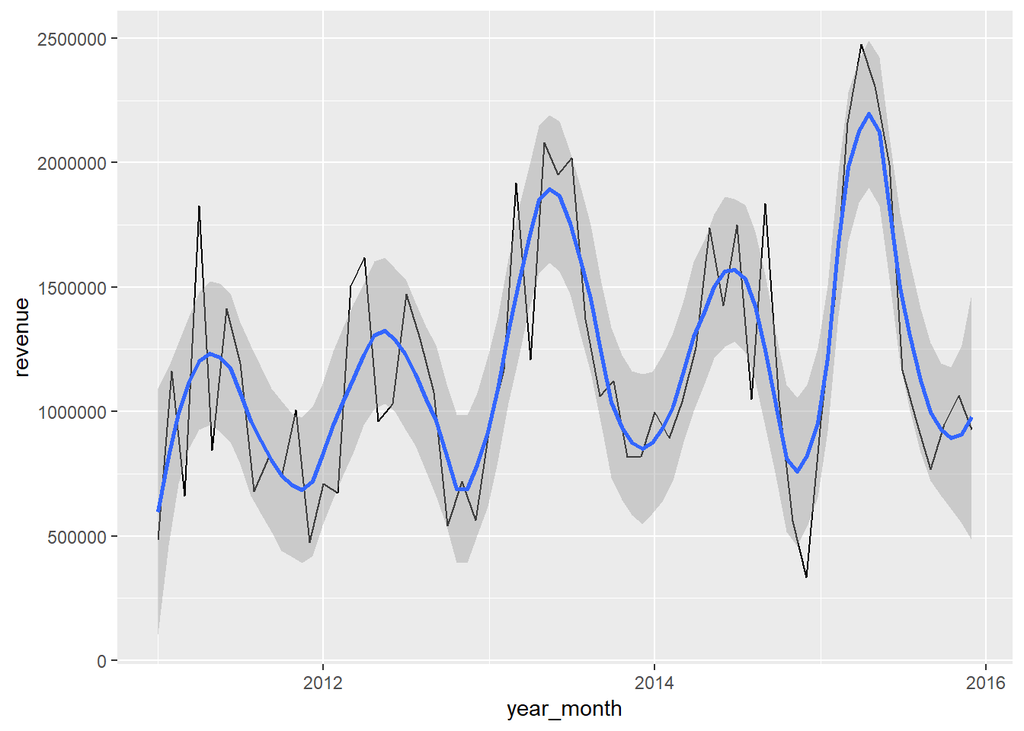

```r
revenue_by_month_tbl %>%
    ggplot(aes(year_month, revenue)) +
    geom_line(size = 0.5, linetype = 1) +
    geom_smooth(method = "loess", span = 0.2)
```

# Line Plot(Describe revenue by Month, expose cyclic nature)

用aes設定X與Y軸

用geom_linet函數畫線

geom_smooth函數畫平滑線(loess - 曲線)

```r
revenue_by_category_2_tbl <- bike_orderlines_tbl %>%
    select(category_2, total_price) %>%
    group_by(category_2) %>%
    summarize(revenue = sum(total_price)) %>%
    ungroup()
```

# Data Manipulation(Sales by Descriptive Category)

用select函數選擇需要的欄位

用summarize函數總整所有資料

用group_by函數 - 群組起來

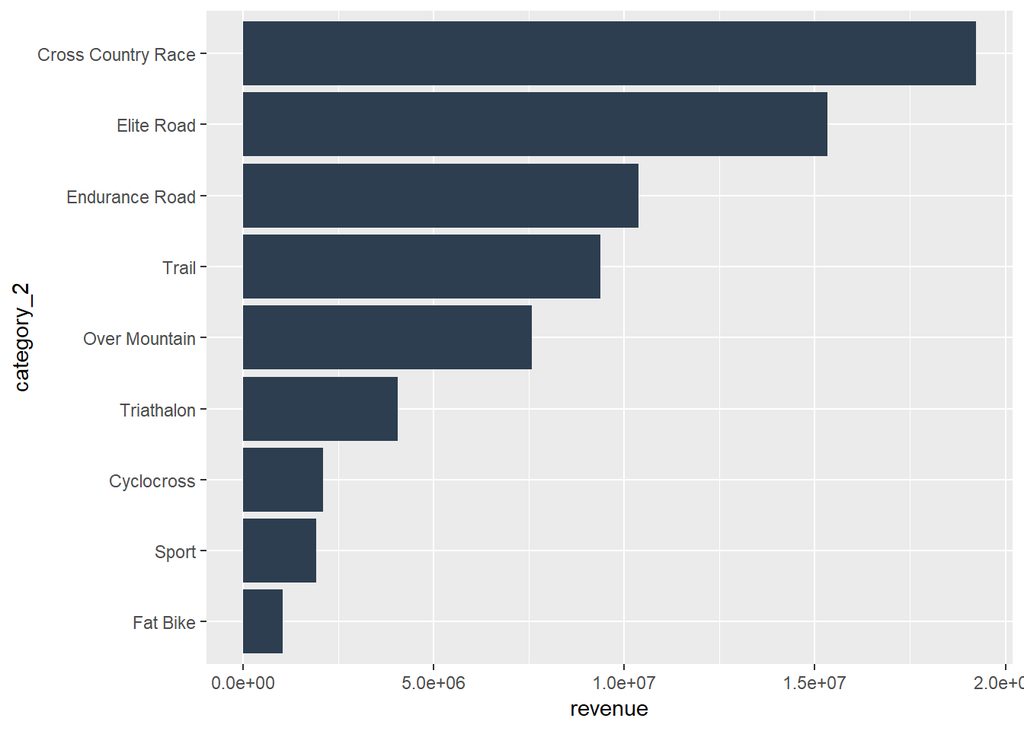

```r
revenue_by_category_2_tbl %>%
    mutate(category_2 = category_2 %>% as_factor() %>% fct_reorder(revenue)) %>%
    ggplot(aes(category_2, revenue)) +
    geom_col(fill = "#2c3e50") +
    coord_flip()
```

# Bar Plot(Sales by Descriptive Category)

用mutate函數新增新的欄位資料

geom_col函數畫欄

coord_flip()函數 - X與Y軸對調

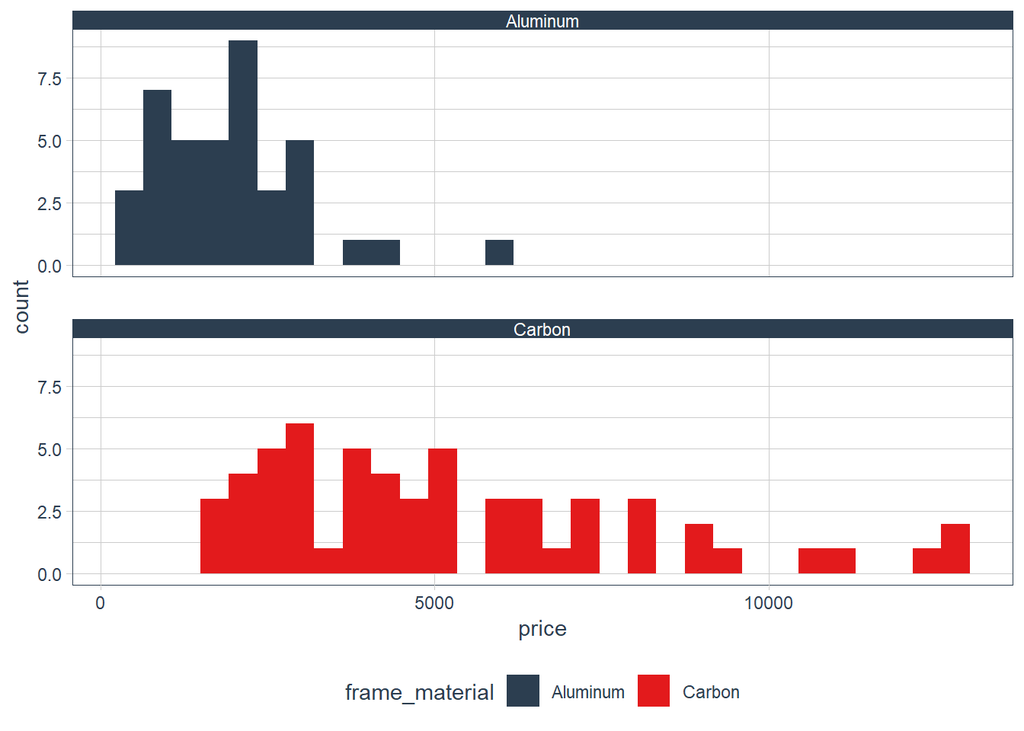

```r
bike_orderlines_tbl %>%
    distinct(price, model, frame_material) %>%
    ggplot(aes(price, fill = frame_material)) +
    geom_histogram() +
    facet_wrap(~ frame_material, ncol = 1) +
    scale_fill_tq() +
    theme_tq()
```

# Histogram(Unit price of bicylce, segmenting by frame material)

distinct函數 - 把重複資料刪除取唯一一個

用aes設定X與Y軸

geom_histogram()畫直方圖

scale_fill_tq()、theme_tq() - 用來美化圖表

facet_wrap函數 - 打資料分成很多小圖

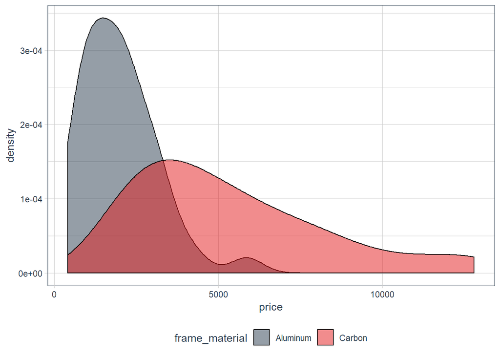

```r
bike_orderlines_tbl %>%
    distinct(price, model, frame_material) %>%
    ggplot(aes(price, fill = frame_material)) +
    geom_density(alpha = 0.5) +
    # facet_wrap(~ frame_material, ncol = 1) +
    scale_fill_tq() +
    theme_tq() +
    theme(legend.position = "bottom")
```

# Density(Unit price of bicylce, segmenting by frame material)

distinct函數 - 把重複資料刪除取唯一一個

用aes設定X與Y軸

geom_density畫曲線分布圖

scale_fill_tq()、theme_tq() - 用來美化圖表

```r
unit_price_by_cat_2_tbl <- bike_orderlines_tbl %>%
    select(category_2, model, price) %>%
    distinct() %>%
    mutate(category_2 = as_factor(category_2) %>% fct_reorder(price))
```

# Data Manipulation(Unit price of model, segmenting by category 2)

distinct函數 - 把重複資料刪除取唯一一個

用select函數選擇需要的欄位

用mutate函數新增新的欄位資料

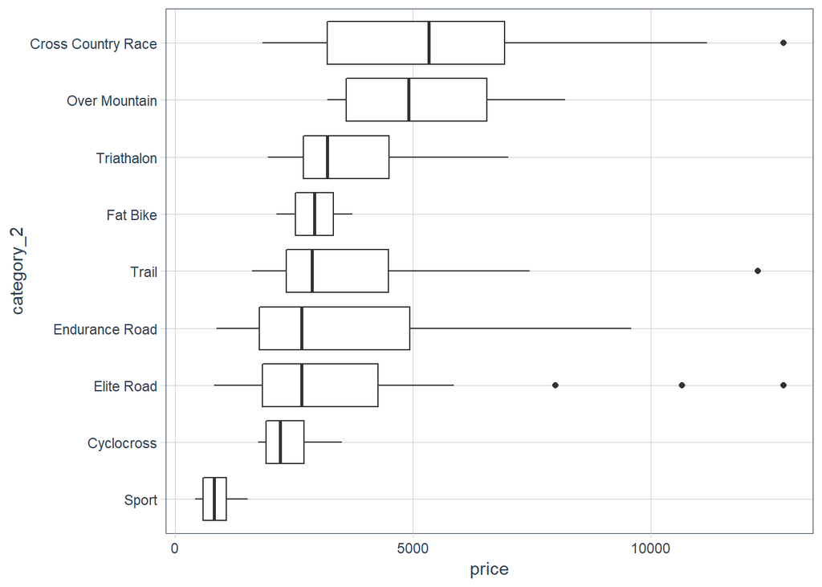

```r
unit_price_by_cat_2_tbl %>%
    ggplot(aes(category_2, price)) +
    geom_boxplot() +
    coord_flip() +
    theme_tq()
```

# Box Plot(Unit price of model, segmenting by category 2)

用aes設定X與Y軸

geom_boxplot畫盒狀圖

coord_flip()函數 - X與Y軸對調

theme_tq()美化圖表

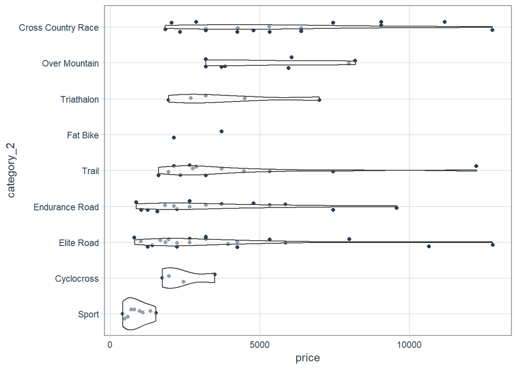

```r
unit_price_by_cat_2_tbl %>%
    ggplot(aes(category_2, price)) +
    geom_jitter(width = 0.15, color = "#2c3e50") +
    geom_violin(alpha = 0.5) +
    coord_flip() +
    theme_tq()
```

# Violin Plot & Jitter Plot(Unit price of model, segmenting by category 2)

用aes設定X與Y軸

coord_flip()函數 - X與Y軸對調

theme_tq()美化圖表

```r
revenue_by_year_tbl <- bike_orderlines_tbl %>%
    select(order_date, total_price) %>%
    mutate(year = year(order_date)) %>%
    group_by(year) %>%
    summarize(revenue = sum(total_price)) %>%
    ungroup()
```

# Data Manipulation(Exposing sales over time, highlighting outlier)

用select函數選擇需要的欄位

用mutate函數新增新的欄位資料

用summarize函數總整所有資料

用group_by函數 - 群組起來

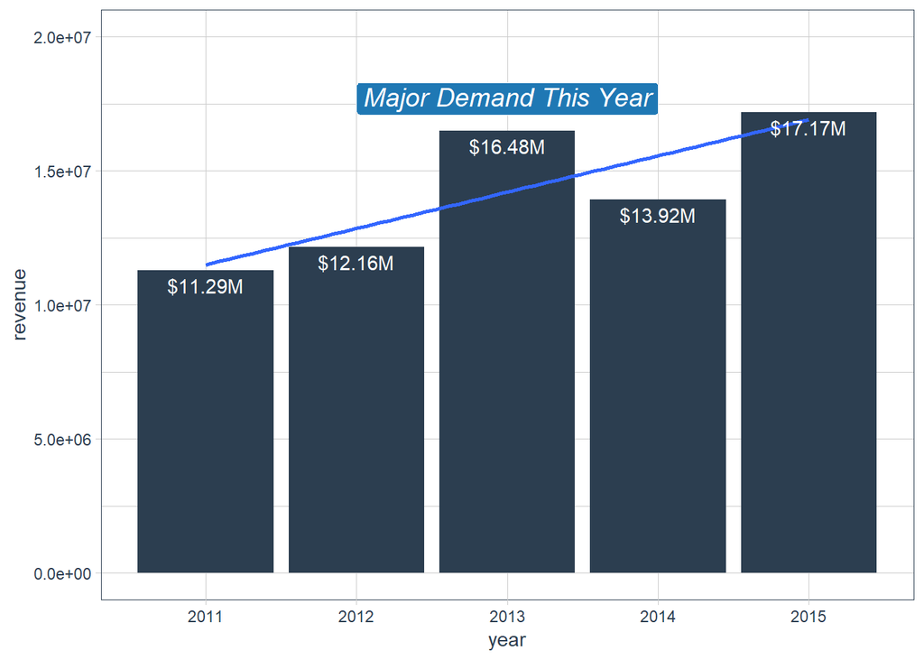

```r
revenue_by_year_tbl %>%
    # mutate(revenue_text = scales::dollar(revenue, scale = 1e-6, suffix = "M")) %>%
    ggplot(aes(year, revenue)) +
    geom_col(fill = "#2c3e50") +
    geom_smooth(method = "lm", se = FALSE) +
    geom_text(aes(label =  scales::dollar(revenue, scale = 1e-6, suffix = "M")),
              vjust = 1.5, color = "white") +
    geom_label(label =  "Major Demand This Year",
               vjust = -0.5,
               size  = 5,
               fill  = "#1f78b4",
               color = "white",
               fontface = "italic",
               data = revenue_by_year_tbl %>%
                   filter(year %in% c(2013))) +
    expand_limits(y = 2e7) +
    theme_tq()
```

# Filtering labels to highlight a point(Exposing sales over time, highlighting outlier)

用aes設定X與Y軸

geom_col函數畫欄

geom_smooth函數畫平滑線

用geom_text函數把文字標示在圖表上

用geom_label函數修改標籤資料

theme_tq()美化圖表